# Analyzing somatic mutations in RNA-seq data

Yang Hu

2017/5/3

## Abstract

It is part of a workflow for analyzing RNA-seq data from Waldenstrom Macroglobulinemia patients, in a cohort called “zhunter,” from Harvard University. After Alignment, samtools sort, VarScan and Annotation, an annotated zhunter_Annotated.eff(data).vcf is generated like below:

| #CHROM | POS | ID | REF | ALT | QUAL | FILTER | INFO | FORMAT | ZH10_NWM07_CTTGTA_L005_R1_001 | … |
| --- | --- | --- | --- | --- | --- | --- | --- | --- | --- | --- |
| chr11 | 47376915 | . | G | C | . | PASS | ..EFF=missense_variant.. | GT:GQ:SDP:DP:RD:AD:FREQ:PVAL:RBQ:ABQ:RDF:RDR:ADF:ADR | 0/0:22:11:11:11:0:0%:1E0:39:0:7:4:0:0 |  |

In part A, script will add gene name, label “MISSENSE/NONSENSE” , extract FREQ%, add counts, and filter out SNP like below:

| CHROM | POS | gene_POS | gene | ID | REF | ALT | QUAL | FILTER | INFO | counts | ZH10_NWM07_CTTGTA_L005_R1_001 | … |
| --- | --- | --- | --- | --- | --- | --- | --- | --- | --- | --- | --- | --- |
| chr11 | 47376915 | SPI1 47376915 | SPI1 | . | G | C | . | PASS | MISSENSE | 9 | 0 | .. |

In part B, script will read FPKM results and cluster somatic mutations.

## A) Reading Annotated vcf, add gene names and annotations

#### A-1) Setup enviroment

```r
setwd("/Users/yah2014/Dropbox/Public/Olivier/R/zhunter/Mutation");getwd();list.files() #set_up_enviroment
```

```
## [1] "/Users/yah2014/Dropbox/Public/Olivier/R/zhunter/Mutation"
```

```
##  [1] "AnnotatedVcf.csv"
##  [2] "AnnotatedVcf_COSM.csv"
##  [3] "AnnotatedVcf_COSM.xls"
##  [4] "AnnotatedVcf_new.csv"
##  [5] "AnnotatedVcf_noval.csv"
##  [6] "AnnotatedVcf_noval.xls"
##  [7] "AnnotatedVcf_novel.csv"
##  [8] "AnnotatedVcf_novel.xls"
##  [9] "AnnotatedVcf_zhunter_COSM.csv"
## [10] "AnnotatedVcf_zhunter_new.csv"
## [11] "AnnotatedVcf_zhunter_novel.csv"
## [12] "Final"
## [13] "Mut_counts.name2.txt"
## [14] "SampleList_zhunter.txt"
## [15] "SampleList_zhunter_name.txt"
## [16] "WM.bed"
## [17] "muta.csv"
## [18] "mutatations.csv"
## [19] "zhunter_Annotated.eff.vcf"
## [20] "zhunter_Annotated.eff20170416.vcf"
## [21] "zhunter_Annotated.eff20170417.vcf"
## [22] "zhunter_snpEff_summary.html"
```

```r
SampleList_zhunter <- read.csv("SampleList_zhunter.txt", header=T)#Get_SampleList_zhunter_Data
SampleList_zhunter_name<- read.csv("SampleList_zhunter_name.txt", header=T)
AnnotatedVcf_zhunter <- read.csv("zhunter_Annotated.eff20170416.vcf",sep="\t",header =T) #Get zhunter_Annotated.eff.vcf
dim(AnnotatedVcf_zhunter)
```

```
## [1] 1415   84
```

Generate a new file `AnnotatedVcf_zhunter_new.csv`.

```r
AnnotatedVcf_zhunter_new <-AnnotatedVcf_zhunter[,1:2]
```

#### A-2) Add gene names

```r
AnnotatedVcf_zhunter_new[,"gene_POS"]<-NA #add a empty column to a dataframe
colnames(AnnotatedVcf_zhunter_new)[1]<-"CHROM" # was #CHORM previously
for(i in 1:(dim(AnnotatedVcf_zhunter)[1]-1)){
    if (AnnotatedVcf_zhunter_new[i,"POS"] >= 27022522 && AnnotatedVcf_zhunter_new[i,"POS"] <=27108601 && AnnotatedVcf_zhunter_new[i,"CHROM"]=="chr1")
        {AnnotatedVcf_zhunter_new[i,"gene_POS"] <- paste0("ARID1A ",AnnotatedVcf_zhunter_new[i,"POS"])
        AnnotatedVcf_zhunter_new[i,"gene"] <- "ARID1A"}
    else if(AnnotatedVcf_zhunter_new[i,"POS"] >= 136871919 && AnnotatedVcf_zhunter_new[i,"POS"] <=136873813 && AnnotatedVcf_zhunter_new[i,"CHROM"]=="chr2")
        {AnnotatedVcf_zhunter_new[i,"gene_POS"] <- paste0("CXCR4 ",AnnotatedVcf_zhunter_new[i,"POS"])
        AnnotatedVcf_zhunter_new[i,"gene"] <- "CXCR4"}
    else if(AnnotatedVcf_zhunter_new[i,"POS"] >= 38179969 && AnnotatedVcf_zhunter_new[i,"POS"] <=38184512 && AnnotatedVcf_zhunter_new[i,"CHROM"]=="chr3")
        {AnnotatedVcf_zhunter_new[i,"gene_POS"] <- paste0("MYD88 ",AnnotatedVcf_zhunter_new[i,"POS"]);
        AnnotatedVcf_zhunter_new[i,"gene"] <- "MYD88"}
    else if(AnnotatedVcf_zhunter_new[i,"POS"] >= 2743387 && AnnotatedVcf_zhunter_new[i,"POS"] <=2757752 && AnnotatedVcf_zhunter_new[i,"CHROM"]=="chr4")
        {AnnotatedVcf_zhunter_new[i,"gene_POS"] <- paste0("TNIP2 ",AnnotatedVcf_zhunter_new[i,"POS"]);
        AnnotatedVcf_zhunter_new[i,"gene"] <- "TNIP2"}
    else if(AnnotatedVcf_zhunter_new[i,"POS"] >= 78432907 && AnnotatedVcf_zhunter_new[i,"POS"] <=78532988 && AnnotatedVcf_zhunter_new[i,"CHROM"]=="chr4")
        {AnnotatedVcf_zhunter_new[i,"gene_POS"] <- paste0("CXCL13 ",AnnotatedVcf_zhunter_new[i,"POS"]);
        AnnotatedVcf_zhunter_new[i,"gene"] <- "CXCL13"}
    else if(AnnotatedVcf_zhunter_new[i,"POS"] >= 121613068 && AnnotatedVcf_zhunter_new[i,"POS"] <=121844021 && AnnotatedVcf_zhunter_new[i,"CHROM"]=="chr4")
        {AnnotatedVcf_zhunter_new[i,"gene_POS"] <- paste0("PRDM5 ",AnnotatedVcf_zhunter_new[i,"POS"]);
        AnnotatedVcf_zhunter_new[i,"gene"] <- "PRDM5"}
    else if(AnnotatedVcf_zhunter_new[i,"POS"] >= 122052564 && AnnotatedVcf_zhunter_new[i,"POS"] <=122137782 && AnnotatedVcf_zhunter_new[i,"CHROM"]=="chr4")
        {AnnotatedVcf_zhunter_new[i,"gene_POS"] <- paste0("TNIP3 ",AnnotatedVcf_zhunter_new[i,"POS"]);
        AnnotatedVcf_zhunter_new[i,"gene"] <- "TNIP3"}
    else if(AnnotatedVcf_zhunter_new[i,"POS"] >= 150409504 && AnnotatedVcf_zhunter_new[i,"POS"] <=150460645 && AnnotatedVcf_zhunter_new[i,"CHROM"]=="chr5")
        {AnnotatedVcf_zhunter_new[i,"gene_POS"] <- paste0("TNIP1 ",AnnotatedVcf_zhunter_new[i,"POS"])
        AnnotatedVcf_zhunter_new[i,"gene"] <- "TNIP1"}
    else if(AnnotatedVcf_zhunter_new[i,"POS"] >= 143072604 && AnnotatedVcf_zhunter_new[i,"POS"] <=143266338 && AnnotatedVcf_zhunter_new[i,"CHROM"]=="chr6")
        {AnnotatedVcf_zhunter_new[i,"gene_POS"] <- paste0("HIVEP2 ",AnnotatedVcf_zhunter_new[i,"POS"]);
        AnnotatedVcf_zhunter_new[i,"gene"] <- "HIVEP2"}
    else if(AnnotatedVcf_zhunter_new[i,"POS"] >= 95947212 && AnnotatedVcf_zhunter_new[i,"POS"] <=96081655 && AnnotatedVcf_zhunter_new[i,"CHROM"]=="chr22")
        {AnnotatedVcf_zhunter_new[i,"gene_POS"] <- paste0("IGLL5 ",AnnotatedVcf_zhunter_new[i,"POS"])
        AnnotatedVcf_zhunter_new[i,"gene"] <- "IGLL5"}
    else if(AnnotatedVcf_zhunter_new[i,"POS"] >= 38177969 && AnnotatedVcf_zhunter_new[i,"POS"] <=38186512 && AnnotatedVcf_zhunter_new[i,"CHROM"]=="chr9")
        {AnnotatedVcf_zhunter_new[i,"gene_POS"] <- paste0("WNK2 ",AnnotatedVcf_zhunter_new[i,"POS"])
        AnnotatedVcf_zhunter_new[i,"gene"] <- "WNK2"}
    else if(AnnotatedVcf_zhunter_new[i,"POS"] >= 44953899 && AnnotatedVcf_zhunter_new[i,"POS"] <=44971759 && AnnotatedVcf_zhunter_new[i,"CHROM"]=="chr11")
        {AnnotatedVcf_zhunter_new[i,"gene_POS"] <- paste0("TP53I11 ",AnnotatedVcf_zhunter_new[i,"POS"])
        AnnotatedVcf_zhunter_new[i,"gene"] <- "TP53I11"}
    else if(AnnotatedVcf_zhunter_new[i,"POS"] >= 47376409 && AnnotatedVcf_zhunter_new[i,"POS"] <=47400127 && AnnotatedVcf_zhunter_new[i,"CHROM"]=="chr11")
        {AnnotatedVcf_zhunter_new[i,"gene_POS"] <- paste0("SPI1 ",AnnotatedVcf_zhunter_new[i,"POS"])
        AnnotatedVcf_zhunter_new[i,"gene"] <- "SPI1"}
    else if(AnnotatedVcf_zhunter_new[i,"POS"] >= 53773979 && AnnotatedVcf_zhunter_new[i,"POS"] <=53810226 && AnnotatedVcf_zhunter_new[i,"CHROM"]=="chr12")
        {AnnotatedVcf_zhunter_new[i,"gene_POS"] <- paste0("SP1 ",AnnotatedVcf_zhunter_new[i,"POS"])
        AnnotatedVcf_zhunter_new[i,"gene"] <- "SP1 "}
    else if(AnnotatedVcf_zhunter_new[i,"POS"] >= 43699412 && AnnotatedVcf_zhunter_new[i,"POS"] <=43785354 && AnnotatedVcf_zhunter_new[i,"CHROM"]=="chr15")
        {AnnotatedVcf_zhunter_new[i,"gene_POS"] <- paste0("TP53BP1 ",AnnotatedVcf_zhunter_new[i,"POS"])
        AnnotatedVcf_zhunter_new[i,"gene"] <- "TP53BP1"}
    else if(AnnotatedVcf_zhunter_new[i,"POS"] >= 7571720 && AnnotatedVcf_zhunter_new[i,"POS"] <=7590868 && AnnotatedVcf_zhunter_new[i,"CHROM"]=="chr17")
        {AnnotatedVcf_zhunter_new[i,"gene_POS"] <- paste0("TP53 ",AnnotatedVcf_zhunter_new[i,"POS"])
        AnnotatedVcf_zhunter_new[i,"gene"] <- "TP53"}
    else if(AnnotatedVcf_zhunter_new[i,"POS"] >= 20715727 && AnnotatedVcf_zhunter_new[i,"POS"] <=20840434 && AnnotatedVcf_zhunter_new[i,"CHROM"]=="chr18")
        {AnnotatedVcf_zhunter_new[i,"gene_POS"] <- paste0("CABLES1 ",AnnotatedVcf_zhunter_new[i,"POS"])
        AnnotatedVcf_zhunter_new[i,"gene"] <- "CABLES1"}
    else if(AnnotatedVcf_zhunter_new[i,"POS"] >= 23229960 && AnnotatedVcf_zhunter_new[i,"POS"] <=23238013 && AnnotatedVcf_zhunter_new[i,"CHROM"]=="chr22")
        {AnnotatedVcf_zhunter_new[i,"gene_POS"] <- paste0("IGLL5 ",AnnotatedVcf_zhunter_new[i,"POS"])
        AnnotatedVcf_zhunter_new[i,"gene"] <- "IGLL5"}
    else {AnnotatedVcf_zhunter_new[i,"gene_POS"] <- paste0(i," ",AnnotatedVcf_zhunter_new[i,"POS"])
        AnnotatedVcf_zhunter_new[i,"gene"] <- NA}
}
AnnotatedVcf_zhunter<-AnnotatedVcf_zhunter[!is.na(AnnotatedVcf_zhunter_new[,"gene"]),]
AnnotatedVcf_zhunter_new<-AnnotatedVcf_zhunter_new[!is.na(AnnotatedVcf_zhunter_new[,"gene"]),]
rownames(AnnotatedVcf_zhunter_new)<-AnnotatedVcf_zhunter_new[,"gene_POS"]
```

#### A-3) Add MISSENSE & NONSSENSE annotations

```r
AnnotatedVcf_zhunter_new<-cbind(AnnotatedVcf_zhunter_new,AnnotatedVcf_zhunter[,3:7])

AnnotatedVcf_zhunter_new[,"INFO"]<-NA #add a empty column to a dataframe
AnnotatedVcf_zhunter_new[grep("MISSENSE",AnnotatedVcf_zhunter[,"INFO"]),"INFO"]<-"MISSENSE"  #Add MISSENSE INFO
AnnotatedVcf_zhunter_new[grep("NONSENSE",AnnotatedVcf_zhunter[,"INFO"]),"INFO"]<-"NONSENSE" #Add MISSENSE INFO
intersect <- intersect(grep("NONSENSE",AnnotatedVcf_zhunter[,"INFO"]),grep("MISSENSE",AnnotatedVcf_zhunter[,"INFO"])) #find intersect
AnnotatedVcf_zhunter_new[intersect,"INFO"]<-"MISSENSE & NONSENSE" #Add both
```

#### A-4) Extract FREQ% data from column 10 to 84

```r
library(stringr)
AnnotatedVcf_zhunter_new[,"counts"]<-NA #add a empty column to a dataframe
Sample<-AnnotatedVcf_zhunter[,c(10,11)] #Generate a temp dataframe with correct dimension
colnames(Sample)<-c("Sample1","Sample2")
for(i in 1:75){
    Sample[,"Sample1"]<-str_split_fixed(AnnotatedVcf_zhunter[,i+9], ":", 14)[,7] #Split column and only extract FREQ%
    Sample[,"Sample1"]<-as.numeric(sub("%","",Sample[,"Sample1"])) #convert character of percentage into numeric
    Sample[,"Sample1"][is.na(Sample[,"Sample1"])]<- 0 #replace NA values with zeros
    AnnotatedVcf_zhunter_new <- cbind(AnnotatedVcf_zhunter_new, Sample[,"Sample1"])
    colnames(AnnotatedVcf_zhunter_new)[i+11] <-as.character(SampleList_zhunter_name[i,]) #rename columns
}
```

#### A-5) Add counts

`Counts` are the total occurrence in 75 samples for one specific mutation.

```r
counting <-function(x){#input is [1,85] vector
    c = 0
    for(i in 1:(ncol(x)-11)){ #"Counts" is at column 11
        if(x[1,i+11]>0) # total occurrence of >0%
            c<-c+1
        }
    return(c)
    }
for(i in 1:nrow(AnnotatedVcf_zhunter_new)){
    AnnotatedVcf_zhunter_new[i,"counts"]<-counting(AnnotatedVcf_zhunter_new[i,]) #
}
```

#### A-6) Filter out regular SNP

Generate file `AnnotatedVcf_zhunter_COSM.csv` contains COSM mutations only.  
Generate file `AnnotatedVcf_zhunter_novel.csv` contains “COSM || MISSENSE || NONSENSE” mutations only.

```r
AnnotatedVcf_zhunter_COSM <- AnnotatedVcf_zhunter_new[grep("COSM",AnnotatedVcf_zhunter_new[,"ID"]),]
AnnotatedVcf_zhunter_novel <- AnnotatedVcf_zhunter_new[AnnotatedVcf_zhunter_new[,"ID"] %in% ".",]
AnnotatedVcf_zhunter_novel<- AnnotatedVcf_zhunter_novel[c(grep("MISSENSE",AnnotatedVcf_zhunter_novel[,"INFO"]),
                                        grep("NONSENSE",AnnotatedVcf_zhunter_novel[,"INFO"])),]
AnnotatedVcf_zhunter_novel<- rbind(AnnotatedVcf_zhunter_COSM,AnnotatedVcf_zhunter_novel)
AnnotatedVcf_zhunter_novel<- AnnotatedVcf_zhunter_novel[order(rownames(AnnotatedVcf_zhunter_novel)),]
AnnotatedVcf_zhunter_novel<- AnnotatedVcf_zhunter_novel[unique(AnnotatedVcf_zhunter_novel[,"gene_POS"]),]
```

#### A-6) Export csv files

```r
write.csv(AnnotatedVcf_zhunter_new,"AnnotatedVcf_zhunter_new.csv")
write.csv(AnnotatedVcf_zhunter_COSM,"AnnotatedVcf_zhunter_COSM.csv")
write.csv(AnnotatedVcf_zhunter_novel,"AnnotatedVcf_zhunter_novel.csv")
```

## B) Analyzing somatic mutations using FPKM

#### B-1) Setup enviroment and Get FPKM_zhunter Data

Read each `genes.FPKM_tracking` data into the file `FPKM_zhunter_temp.csv`.  
Generate file `FPKM_zhunter` contains FPKM data from 1st sample only.

```r
FPKM_zhunter_files_path <-paste0("/Users/yah2014/Documents/Programs/R/FPKM/", #Create FPKM_zhunter_files_path file contains folder names
                         SampleList_zhunter$Sample_ID,"_CuffLinks/genes.FPKM_tracking")
FPKM_zhunter <-data.frame(x= str(0), y= integer(0)) #Generate empty FPKM_zhunter dataframe
```

```
##  num 0
```

```r
FPKM_zhunter_temp  <- read.csv(FPKM_zhunter_files_path[1], header=T, sep="\t") #Read data from 1st sample
FPKM_zhunter_temp <- FPKM_zhunter_temp[order(FPKM_zhunter_temp$tracking_id),] #Reorder the gene name
FPKM_zhunter<-FPKM_zhunter_temp$FPKM #Fill up FPKM_zhunter dataframe with tracking id
```

Generate file `FPKM_zhunter` contains FPKM data from all samples. This might take less than one minute.

```r
for(i in 2:nrow(SampleList_zhunter)){ #skip the first one, which is added already
    FPKM_zhunter_temp  <- read.csv(FPKM_zhunter_files_path[i], header=T, sep="\t")
    FPKM_zhunter_temp <- FPKM_zhunter_temp[order(FPKM_zhunter_temp$tracking_id),] #Reorder the gene name
    FPKM_zhunter<-cbind(FPKM_zhunter,FPKM_zhunter_temp$FPKM)
}
```

Rename rows and columns of`FPKM_zhunter`

```r
dim(FPKM_zhunter)
```

```
## [1] 25286    75
```

```r
colnames(FPKM_zhunter) <-SampleList_zhunter_name$Sample_ID # or annotation$SimpleLabel
rownames(FPKM_zhunter) <-FPKM_zhunter_temp$tracking_id

FPKM_name<-data.frame(x= str(0), y= integer(0))
```

```
##  num 0
```

```r
FPKM_name<-as.character(FPKM_zhunter_temp$tracking_id)
FPKM_name<-cbind(FPKM_name,as.character(FPKM_zhunter_temp$tracking_id))
```

#### B-2) Charaterize somatic mutations

Setup envirment

```r
setwd("/Users/yah2014/Dropbox/Public/Olivier/R/zhunter/Mutation");getwd();list.files()
```

```
## [1] "/Users/yah2014/Dropbox/Public/Olivier/R/zhunter/Mutation"
```

```
##  [1] "AnnotatedVcf.csv"
##  [2] "AnnotatedVcf_COSM.csv"
##  [3] "AnnotatedVcf_COSM.xls"
##  [4] "AnnotatedVcf_new.csv"
##  [5] "AnnotatedVcf_noval.csv"
##  [6] "AnnotatedVcf_noval.xls"
##  [7] "AnnotatedVcf_novel.csv"
##  [8] "AnnotatedVcf_novel.xls"
##  [9] "AnnotatedVcf_zhunter_COSM.csv"
## [10] "AnnotatedVcf_zhunter_new.csv"
## [11] "AnnotatedVcf_zhunter_novel.csv"
## [12] "Final"
## [13] "Mut_counts.name2.txt"
## [14] "SampleList_zhunter.txt"
## [15] "SampleList_zhunter_name.txt"
## [16] "WM.bed"
## [17] "muta.csv"
## [18] "mutatations.csv"
## [19] "zhunter_Annotated.eff.vcf"
## [20] "zhunter_Annotated.eff20170416.vcf"
## [21] "zhunter_Annotated.eff20170417.vcf"
## [22] "zhunter_snpEff_summary.html"
```

Run quanlity control with boxplot

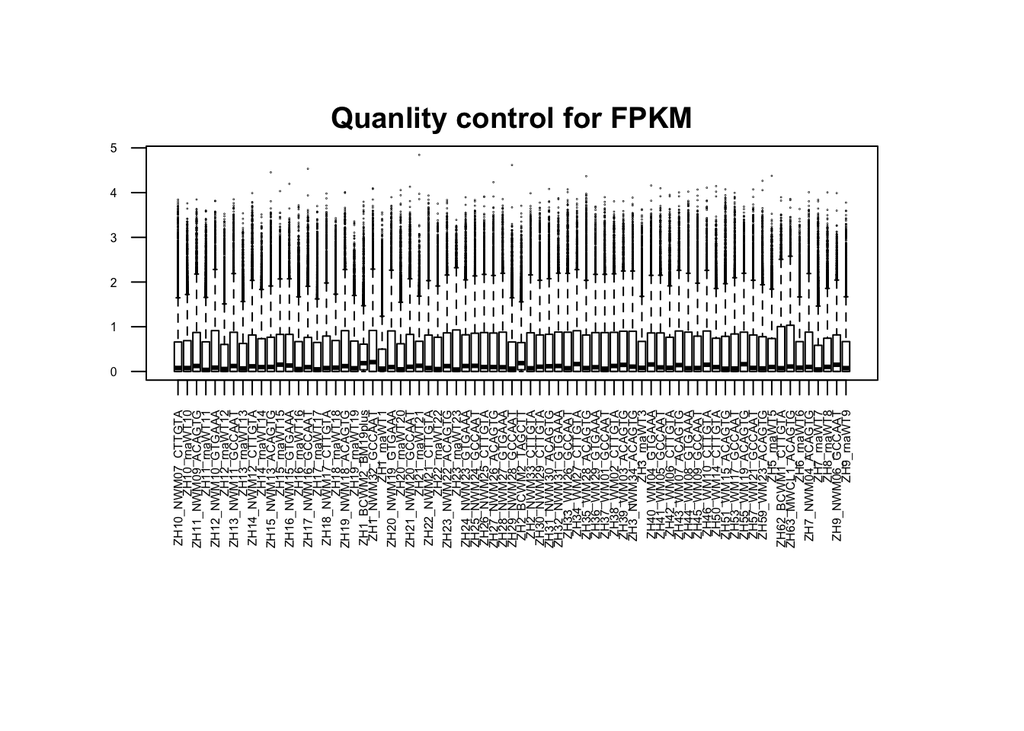

```r
# set a margin
par(oma=c(10,3,3,3))  # all sides have 3 lines of space
par(mar=c(2,2,2,2))
FPKM_zhunter_clean <- FPKM_zhunter[,!(colnames(FPKM_zhunter) %in% c("ZH2_rnaWT2","ZH4_rnaWT4"))] #"ZH2_rnaWT2","ZH4_rnaWT4" have bad quanlity
boxplot(log10(FPKM_zhunter_clean + 1),xlab="all test samples",cex=0.05, cex.axis=0.5, ylab = "log (base 10) RPKM + 1",main="Quanlity control for FPKM",las=2)
```

Group sample with hclust

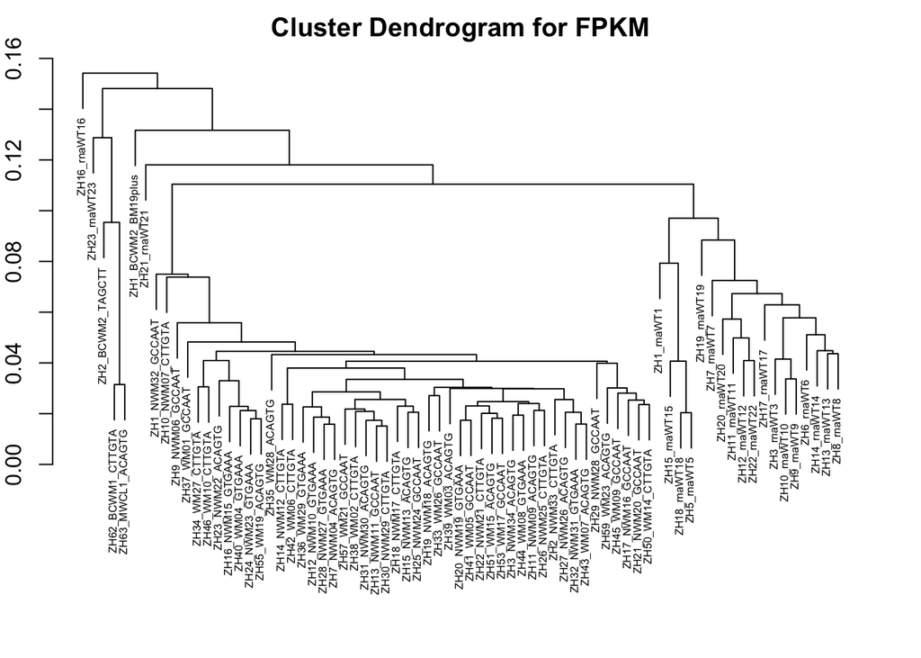

```r
par(mar=c(2,2,2,2))
lm <-log(FPKM_zhunter_clean+1)
dm<-as.dist(1-cor(lm))
hm<-hclust(dm,method = "average")
p<-plot(hm,col = "black",cex = 0.5,main="Cluster Dendrogram for FPKM")
```

Generate heatmap  
Prepare palette

```r
my_palette1 <- colorRampPalette(c("antiquewhite2", "green", "blue"))(n = 100)
my_palette2 <- colorRampPalette(c("red", "green"))(n = 2)
my_palette3 <- colorRampPalette(c("yellow", "orange", "red","green","blue","purple"))(n = 6)
```

Clean up data

```r
mut_gene <- AnnotatedVcf_zhunter_novel[,!(colnames(AnnotatedVcf_zhunter_novel) %in% c("CHROM","POS","gene_POS","gene","ID","REF","ALT","QUAL","FILTER","INFO","counts"))]
mut_gene_clean <- mut_gene[,!(colnames(mut_gene) %in% c("ZH2_rnaWT2","ZH4_rnaWT4"))]
```

Generate heatmap

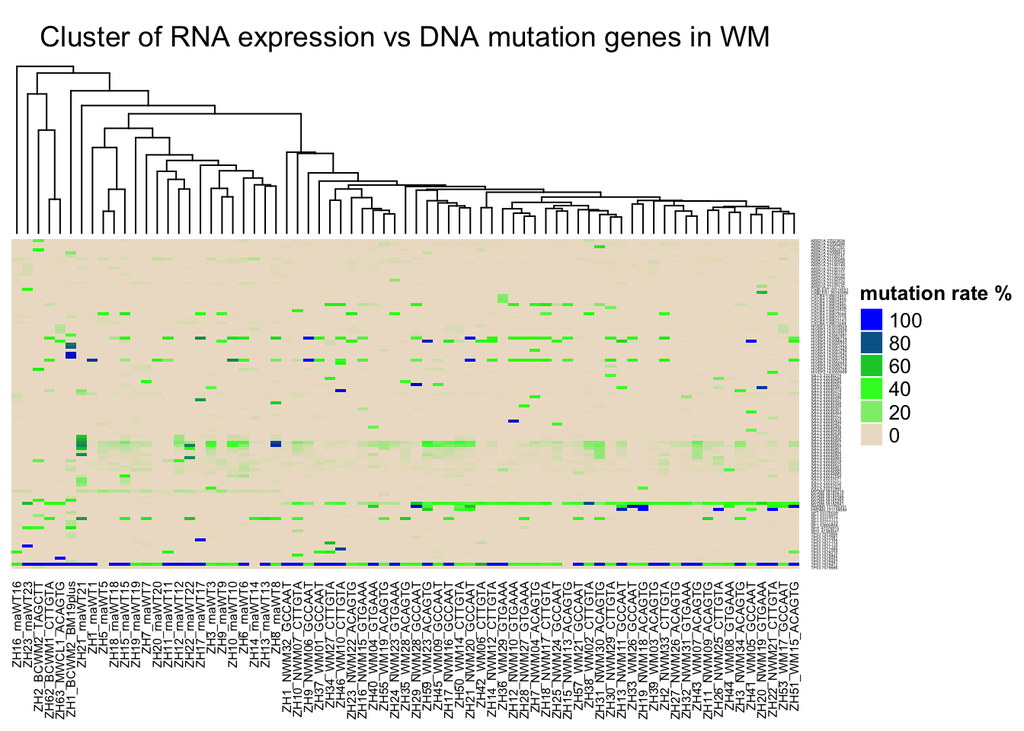

```r
library(gplots)
library(ComplexHeatmap)
par(oma=c(3,3,3,3))
par(mar=c(2,2,2,2)+1)

Heatmap(mut_gene_clean,
        column_title = "Cluster of RNA expression vs DNA mutation genes in WM",
        show_row_names = TRUE,
        col=my_palette1,
        row_title_gp = gpar(fontsize = 14),
        row_names_gp = gpar(fontsize = 2),
        column_names_gp = gpar(fontsize = 6),
        clustering_distance_columns = "euclidean",
        cluster_rows = FALSE,
        cluster_columns =  hm,
        row_dend_width = unit(5, "cm"),
        column_dend_height = unit(30, "mm"),
        heatmap_legend_param = list(title = "mutation rate %")
)
```